# A study of the skewed generalized t-distribution

14:11 18 May 2024

# Estimating the parameters of a sum skewed $t$ distributed r.v’s

```r
num_simulations <- 1000
num_paths <- 10000
num_periods <- 20
sim_params <- c(0.08, 0.12, 3.18, 0.02)
```

Estimated parameters for sum, $S_{20}$:

|  | m | s | nu | xi |
| --- | --- | --- | --- | --- |
| m | 1.605 | 0.522 | 8.856 | 0.653 |
| s | 0.005 | 0.006 | 0.846 | 0.011 |

```r
num_simulations <- 100
num_paths <- 10000
num_periods <- 20
sim_params <- c(0.08, 0.12, 3.18, 0.02)
```

## Estimating the $m$ parameter of the skewed $t$ distribution

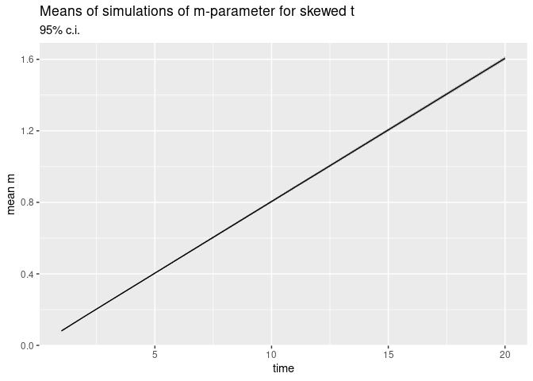

This looks like:

$$m(n) = n \cdot m(0)$$

|  | 1 | 2 | 3 | 4 | 5 | 6 | 7 | 8 | 9 | 10 |
| --- | --- | --- | --- | --- | --- | --- | --- | --- | --- | --- |
| formula | 0.080 | 0.160 | 0.240 | 0.320 | 0.400 | 0.480 | 0.560 | 0.640 | 0.720 | 0.800 |
| m_n | 0.081 | 0.163 | 0.243 | 0.324 | 0.404 | 0.484 | 0.564 | 0.644 | 0.725 | 0.805 |

|  | 11 | 12 | 13 | 14 | 15 | 16 | 17 | 18 | 19 | 20 |
| --- | --- | --- | --- | --- | --- | --- | --- | --- | --- | --- |
| formula | 0.880 | 0.960 | 1.040 | 1.120 | 1.200 | 1.280 | 1.360 | 1.440 | 1.520 | 1.600 |
| m_n | 0.885 | 0.965 | 1.045 | 1.125 | 1.205 | 1.285 | 1.365 | 1.446 | 1.526 | 1.606 |

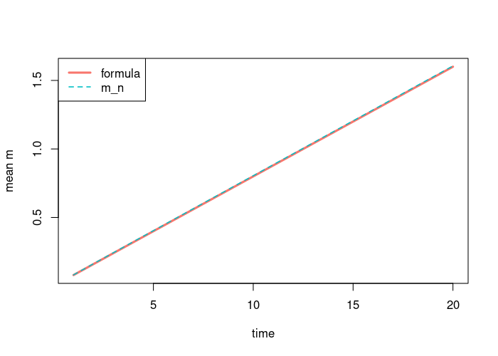

### Verify $m(n) = n \cdot m(0)$

Test if the sample means of a sum of F-S Skewed $t$ r.v.’s are equal to $n$ times the mean of a single r.v. from that distribution.

Even with only 50 samples to estimate the sample mean, the fit is spot on.

```r
num_sim <- 50
n <- 100
mu <- 1.7
sigma <-  2
nu <- 3
xi <- 0.25
```

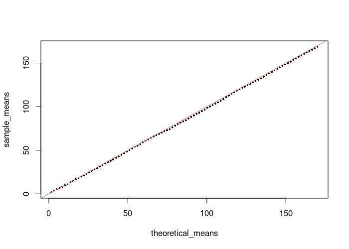

## Estimating the $s$ parameter of the skewed $t$ distribution

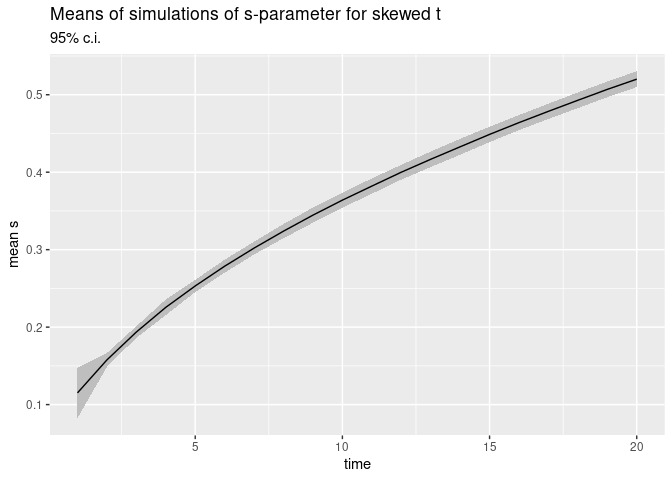

This looks like:

$$s(n) = \sqrt{n s(1)^2}$$

|  | 1 | 2 | 3 | 4 | 5 | 6 | 7 | 8 | 9 | 10 |
| --- | --- | --- | --- | --- | --- | --- | --- | --- | --- | --- |
| formula | 0.120 | 0.170 | 0.208 | 0.240 | 0.268 | 0.294 | 0.317 | 0.339 | 0.360 | 0.379 |
| s_n | 0.115 | 0.158 | 0.194 | 0.226 | 0.253 | 0.279 | 0.302 | 0.324 | 0.345 | 0.364 |

|  | 11 | 12 | 13 | 14 | 15 | 16 | 17 | 18 | 19 | 20 |
| --- | --- | --- | --- | --- | --- | --- | --- | --- | --- | --- |
| formula | 0.398 | 0.416 | 0.433 | 0.449 | 0.465 | 0.480 | 0.495 | 0.509 | 0.523 | 0.537 |
| s_n | 0.382 | 0.400 | 0.417 | 0.433 | 0.449 | 0.464 | 0.479 | 0.493 | 0.507 | 0.520 |

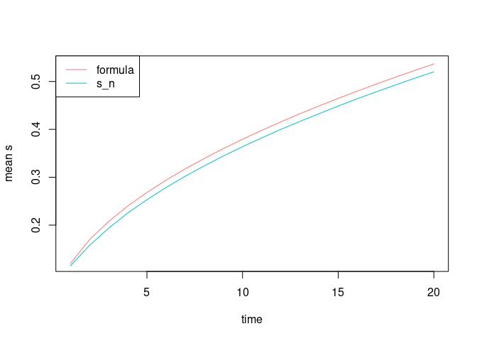

Let’s use that (according to Taleb, ch. 8)
$$\mathbb{M}(n) = n^{1/\tilde{\alpha}}
\mathbb{M}(1) = n^{1/\tilde{\alpha}}\sqrt{\dfrac{2}{\pi}}
\sigma$$
where

$$\tilde{\alpha} = \alpha I\{\alpha <
0\} + 2 I\{\alpha < \geq 0\}$$
for the Power Law class and otherwise

$$\tilde{\alpha} = 2$$

We’ll implement this as formula 1.

Let formula 2 be:
$$\mathbb{M}(n) =
\dfrac{\sum_k^m \lvert S_{n, k} - n \mu_{X_i} \rvert}{n}$$
where $\mu_{X_i}$ is the location parameter we use to generate $\{X_i\}$, and $S_{n, k}$, is the sum of $X_{k,1}, X_{k,2}, \dots, X_{k,n}$ for the $k$’th simulation.

```r
num_simulations <- 1000
num_paths <- 10000
num_periods <- 20
sim_params <- c(0.08, 0.12, 3.18, 0.02)
```

|  | 1 | 2 | 3 | 4 | 5 | 6 | 7 | 8 | 9 | 10 |
| --- | --- | --- | --- | --- | --- | --- | --- | --- | --- | --- |
| f1 | 0.0957 | 0.1191 | 0.1353 | 0.1481 | 0.1588 | 0.1682 | 0.1766 | 0.1841 | 0.1911 | 0.1975 |
| f2 | 0.0743 | 0.1119 | 0.1413 | 0.1662 | 0.1883 | 0.2084 | 0.2268 | 0.2441 | 0.2602 | 0.2755 |
| s_n | 0.0743 | 0.1119 | 0.1413 | 0.1662 | 0.1883 | 0.2083 | 0.2268 | 0.2440 | 0.2602 | 0.2755 |

|  | 11 | 12 | 13 | 14 | 15 | 16 | 17 | 18 | 19 | 20 |
| --- | --- | --- | --- | --- | --- | --- | --- | --- | --- | --- |
| f1 | 0.2035 | 0.2092 | 0.2145 | 0.2196 | 0.2244 | 0.229 | 0.2334 | 0.2376 | 0.2417 | 0.2456 |
| f2 | 0.2902 | 0.3041 | 0.3176 | 0.3305 | 0.3429 | 0.355 | 0.3667 | 0.3781 | 0.3892 | 0.3999 |
| s_n | 0.2901 | 0.3041 | 0.3175 | 0.3304 | 0.3429 | 0.355 | 0.3667 | 0.3780 | 0.3891 | 0.3999 |

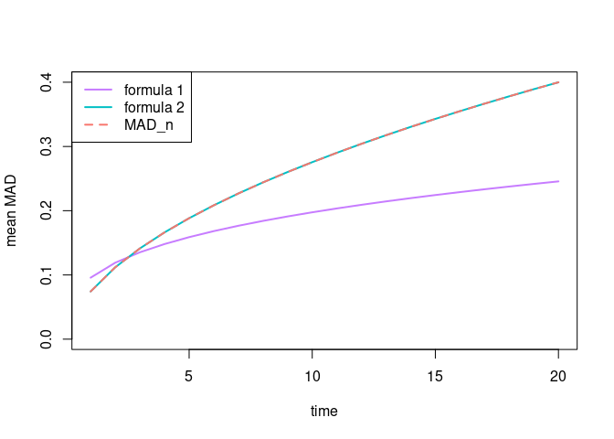

Formula 2 matches the realized MAD of $\{S_{n, k}\}_k^m$ very well.  
Formula 1 matches the realized MAD of $\{S_{n, k}\}_k^m$ very badly.

We notice that:

$$\sqrt{\dfrac{2}{\pi}} \sigma_{X_i} =
0.09575$$

$$\sqrt{\dfrac{2}{\pi}} \hat{\sigma}_{X_i}
= \text{approx.} 0.09$$

```r
sd(rsstd(1e5,
         mean = sim_params[1], sd = sim_params[2], nu = sim_params[3], xi = sim_params[4])
   ) * sqrt(2/pi)
```

```
## [1] 0.09330654
```

while

$$\mathbb{M}(1) =\dfrac{\sum_{k=1}^m
\lvert X_{k, i} - n \overline{X_i} \rvert}{m} = \text{approx.}
0.07$$

```r
f_mad(rsstd(1e5, mean = sim_params[1], sd = sim_params[2], nu = sim_params[3], xi = sim_params[4]))
```

```
## [1] 0.07448496
```

But are we supposed to see that

$$\mathbb{M}(1) =\sqrt{\dfrac{2}{\pi}}
\sigma$$

??

Actually no:

The relation $\mathbb{M}^{\nu}(1) = \sqrt{\frac{2}{\pi}} \sigma$ only holds for the standard normal distribution, and only asymptotically. The ratio $\frac{\text{MAD}(X)}{\text{sd}(X)}$ varies between 0 and 1.

https://en.wikipedia.org/wiki/Average_absolute_deviation#Mean_absolute_deviation_around_the_mean

```r
sd(rsstd(1e5, mean = sim_params[1], sd = sim_params[2], nu = sim_params[3], xi = sim_params[4])) * 2/pi
```

```
## [1] 0.0758978
```

That’s better!

So let’s use this ratio instead:

|  | 1 | 2 | 3 | 4 | 5 | 6 | 7 | 8 | 9 | 10 |
| --- | --- | --- | --- | --- | --- | --- | --- | --- | --- | --- |
| f1 | 0.0764 | 0.1080 | 0.1323 | 0.1528 | 0.1708 | 0.1871 | 0.2021 | 0.2161 | 0.2292 | 0.2416 |
| f2 | 0.0743 | 0.1119 | 0.1413 | 0.1662 | 0.1883 | 0.2084 | 0.2268 | 0.2441 | 0.2602 | 0.2755 |
| s_n | 0.0743 | 0.1119 | 0.1413 | 0.1662 | 0.1883 | 0.2083 | 0.2268 | 0.2440 | 0.2602 | 0.2755 |

|  | 11 | 12 | 13 | 14 | 15 | 16 | 17 | 18 | 19 | 20 |
| --- | --- | --- | --- | --- | --- | --- | --- | --- | --- | --- |
| f1 | 0.2534 | 0.2646 | 0.2754 | 0.2858 | 0.2959 | 0.3056 | 0.3150 | 0.3241 | 0.3330 | 0.3416 |
| f2 | 0.2902 | 0.3041 | 0.3176 | 0.3305 | 0.3429 | 0.3550 | 0.3667 | 0.3781 | 0.3892 | 0.3999 |
| s_n | 0.2901 | 0.3041 | 0.3175 | 0.3304 | 0.3429 | 0.3550 | 0.3667 | 0.3780 | 0.3891 | 0.3999 |

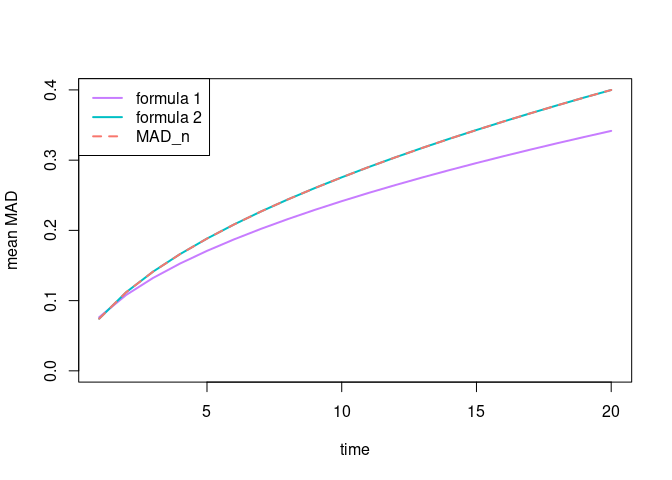

Now formula 1 matches the realized MAD of $\{S_{n, k}\}_k^m$ better, but still not very well.  
Formula 2 is the way to go.

See “taleb_kappa.pdf” for further discussion.

## Estimating the $\nu$ parameter of the skewed $t$ distribution

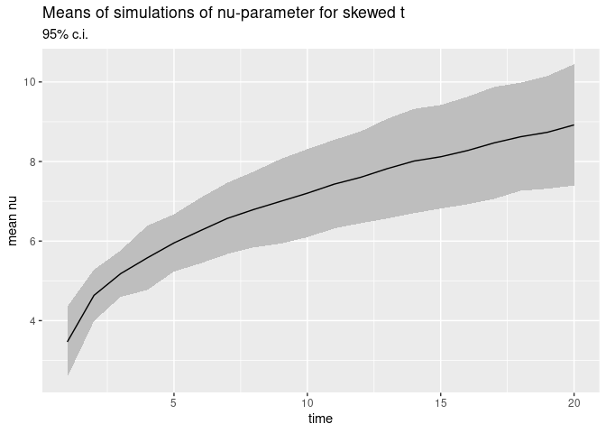

We don’t have a good guess here.

## Estimating the $\xi$ parameter of the skewed $t$ distribution

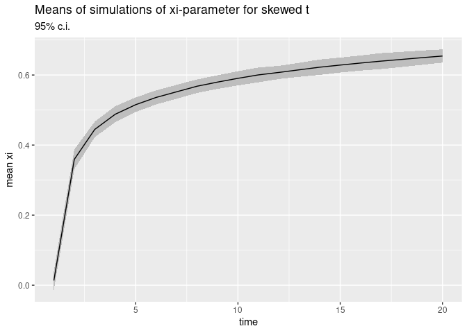

Again, no good guess.

## Analytical m and s from $\alpha$

According to Taleb, the better way to estimate dispersion is to estimate the tail parameter using MLE and then computing the analytical mean and standard deviation as a function of $\nu$.

### Analytical moments

According to `help(std)`, you obtain `sd(rt())` by `sd() / sqrt(nu / (nu - 2))`.

So this should give sd of 1:

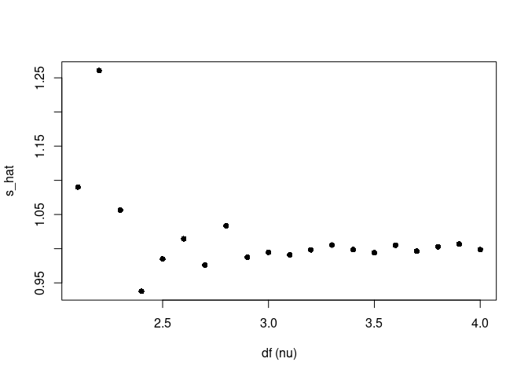

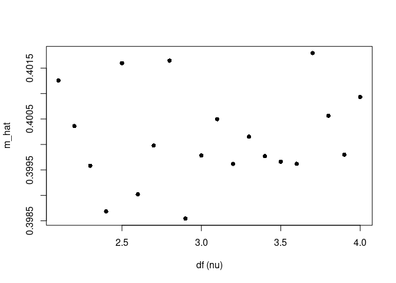

```r
df = 30
x_rt <- ((rt(n = 1e6, df = df) * sqrt((df - 2) / df)) * 0.9 + 0.4)
x_std <- rsstd(n = 1e6, mean = 0.4, sd = 0.9, nu = df)
x_sstd <- rsstd(n = 1e6, mean = 0.4, sd = 0.9, nu = df, xi = 0.2)
```

```r
mean(x_rt)
```

```
## [1] 0.3999944
```

```r
mean(x_std)
```

```
## [1] 0.4004414
```

```r
mean(x_sstd)
```

```
## [1] 0.3999329
```

```r
sd(x_rt)
```

```
## [1] 0.8993699
```

```r
sd(x_std)
```

```
## [1] 0.9008423
```

```r
sd(x_sstd)
```

```
## [1] 0.8993905
```

The mean seems fine for all `df > 2`:

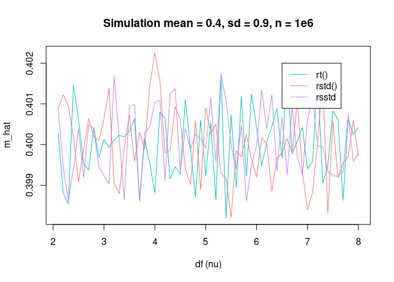

For less than approx. 3 df (nu) it doesn’t hold:

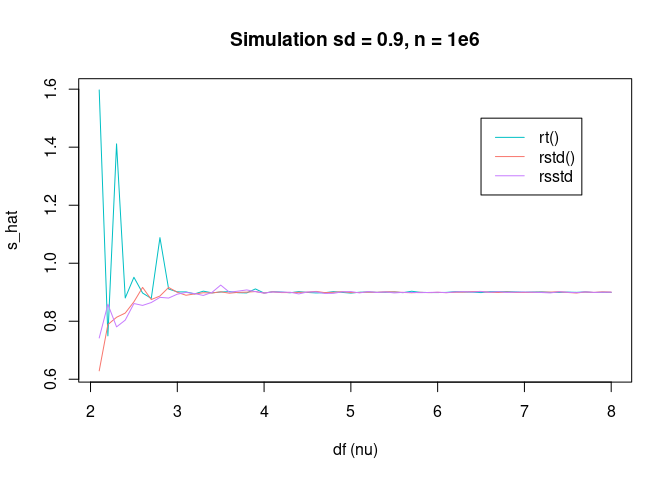

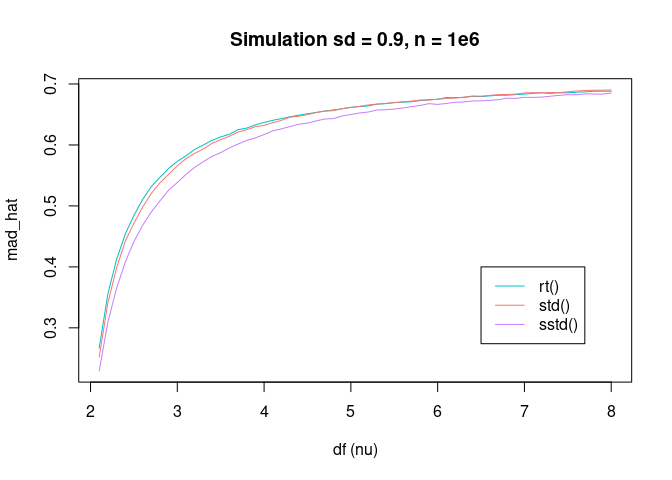

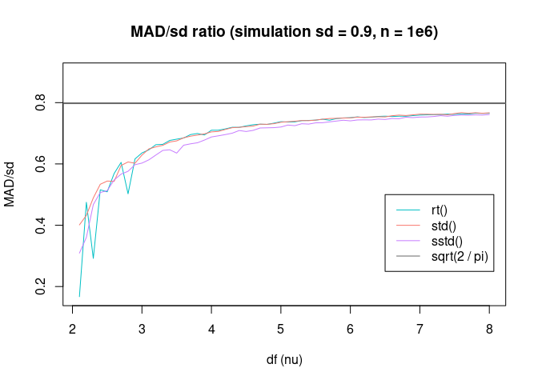

### Analytical mean

“A review of Student’s t distribution and its generalizations.pdf”, p. 10

$$f(x) = \dfrac{2 \xi}{\xi^2 + 1}\dfrac{\Gamma\left(\frac{\nu +
1}{2}\right)}{\sqrt{\pi \nu} \Gamma\left(\frac{\nu}{2}\right)} \left[ 1
+ \dfrac{x^2}{\nu}\left(\dfrac{1}{\xi^2}I\{x \geq 0\} + \xi^2
I\{x<0\} \right)\right]^{-\frac{\nu + 1}{2}}$$

$$\mathbb{E}[X^r] = M_r \dfrac{\xi^{r+1} +
\frac{(-1)^r}{\xi^{r+1}}}{\xi+\frac{1}{\xi}}$$
where

$$M_r = \int_0^{\infty}2 x^r f(x) dx$$

```
## Input mean param: 0.08
```

```
## Analytical mean param:
```

```
## $value
## [1] -0.0008603894
##
## $integration.abs.error
## [1] 2.295918e-05
```

fGarch vignette:

```
## Input mean param: 0.08
```

```
## Analytical mean param:
```

```
## [1] 4.932924e-05
```

### Analytical sd

“A review of Student’s t distribution and its generalizations”

(See above)

```
## Input sd param: 0.12
```

```
## Analytical sd param:
```

```
## $value
## [1] 0.002153768
##
## $integration.abs.error
## [1] 9.062533e-07
```

fGarch vignette:  
“Parameter Estimation of ARMA Models with GARCH/APARCH Errors An R and SPlus Software Implementation”, p. 12

$$f(x \mid \xi) = \dfrac{2}{\xi + \frac{1}{\xi}} \left[f(\xi x) I\{x \geq
0\} + f\left(\dfrac{x}{\xi}\right) I\{x<0\} \right]$$
$$\mu_{\xi} = M_1 \left( \xi - \dfrac{1}{\xi} \right)$$
$$\sigma_{\xi}^2 = (M_2 - M_1^2)\left(\xi^2 + \dfrac{1}{\xi^2} \right) + 2
M_1^2 - M_2$$
where $M_r$ is defined as above.

```
## Input sd param: 0.12
```

```
## Analytical sd param:
```

```
## [1] 7.936333e-06
```

## Convergence

```r
num_simulations <- 100
n_exponent <- 15
sim_params <- c(0.08, 0.12, 3.18, 0.02)
sim_data <- replicate(num_simulations, rsstd(2^n_exponent, sim_params[1], sim_params[2], sim_params[3], sim_params[4]))
```

Simulate parameter estimation

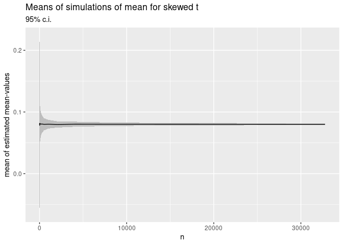

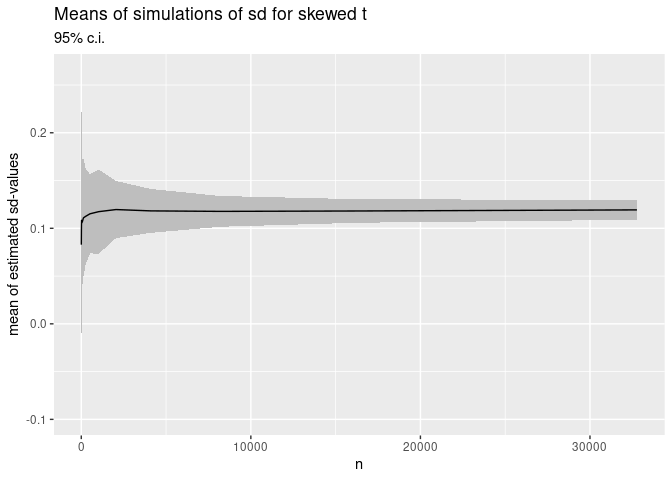

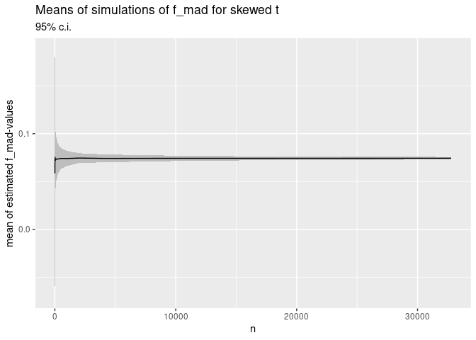

### Compare estimation packages

```r
num_simulations <- 100
n_exponent <- 13
sim_params <- c(0.058, 0.123, 2.265, 0.477) ## pmr
sim_data <- as.data.frame(replicate(num_simulations, rsstd(2^n_exponent, sim_params[1], sim_params[2], sim_params[3], sim_params[4])))
```

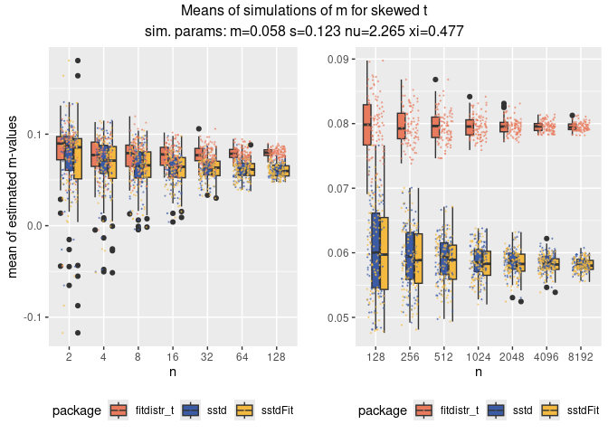

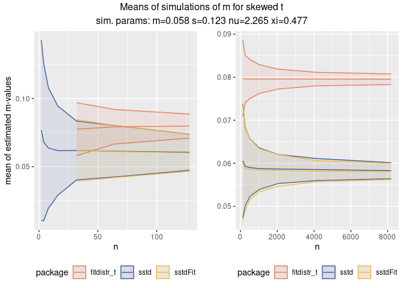

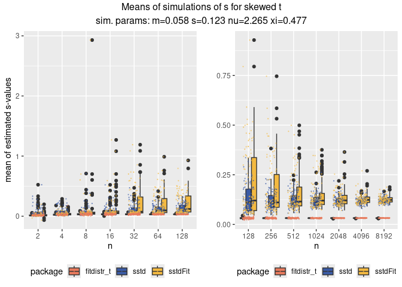

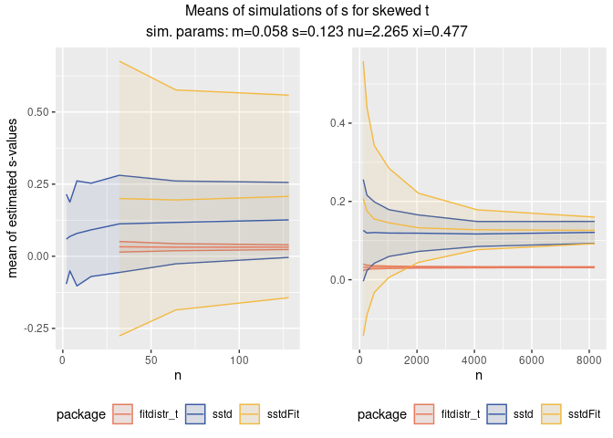

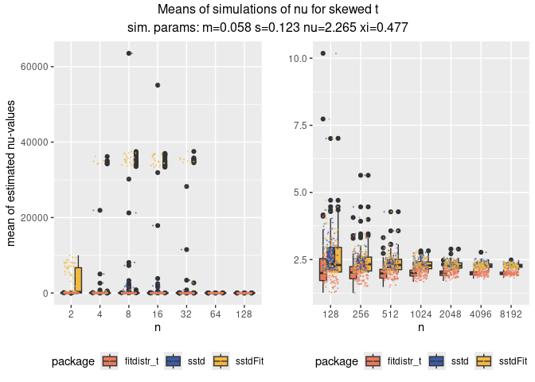

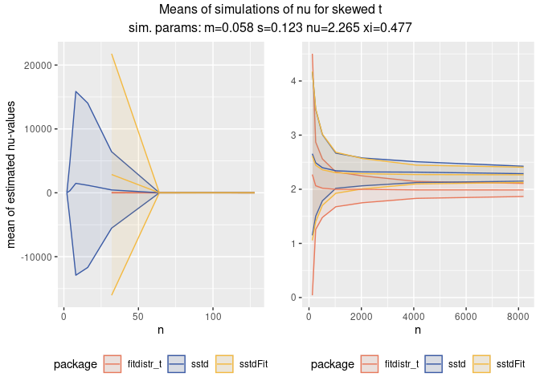

(No boxplot for xi, because fitdistr fits to a t-distribution, i.e. no xi parameter.)

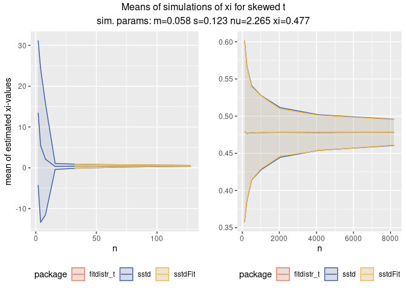

```r
##########################
## Data object dimensions:
##########################
##
## sim_data: 2^n_exponent x num_simulations
## hat_vals: num_simulations x n_exponent
## hat_stats: n_exponent x 5 (n, mean, sd, ci_l, ci_u)
## package_df:
## packages_comparison_list:
##   n_exponent lists containing 1 data frame for each package:
##     each data frame: num_simulations x 4 ("m", "s", "nu", "xi")
##
## hat_vals_list:
##   list of 4 lists, one list for each of ("m", "s", "nu", "xi")
##     list of 3 data frames, one for each package
##       hat_vals data frames: num_simulations x n_exponent
##
## packages_comparison_stats_list:
##   list of 4 lists, one list for each of ("m", "s", "nu", "xi")
##     list of 3 data frames - with hat_stats(hat_vals)
##       each data frame (hat_stats): n_exponent x 5 (n as factor, m, sd, ci_l, ci_u)
##
## From each hat_stats df, make hat_stats_plot
##
## packages_comparison_stats_list_for_plot:
##   list of 4 data frames, one for each of ("m", "s", "nu", "xi"):
##     packages_comparison_stats_df: 3 * n_exponent x 6 (n as factor, m, sd, ci_l, ci_u, package)
```